# match

Maita Schade

Aug 26, 2019

Given a target sample, recoded panel, and possibly previous invites and completes, this notebook produces a new set of panelists to invite, with flexible number of columns (for larger batches).

Make sure we’re dealing with a clear space:

```r
rm(list = ls(all = TRUE))
```

Set the space up. Country is the only thing you should need to set manually, if the files are all set up properly.

```r
country <- "AR"
```

Defining files–make sure the dirs are okay; other than that you shouldn’t need to touch this if the file structure is set up properly.

```r
#strats = ("GEO1_AR2010")
#strat2 = "URBAN"
# wave = 17
# filedate = "190826"

datadir <- paste0('C:/Users/schadem/Box Sync/LAPOP Shared/working documents/maita/Coordination/Noam Argentina Panel/Matching process/Data/',country,'/')



panelfile <- paste0(datadir,'panel/', country, '_netquest_recoded.csv')

recodepath <- paste0("./recode_Netquest_IPUMS_",country, ".csv") #table specifying recodes
parampath <- "./country_parameters.csv" # set specefic parameters in this file

responsefile <- paste0('C:/Users/schadem/Box Sync/LAPOP Shared/working documents/maita/Coordination/Noam Argentina Panel/Data processing/Data/APE_2019_sept7v2_September 27, 2019_01.02.csv')
#file of not yet sent IDs
recyclefile <- paste0(datadir, "panel/AR_selected_wave1_QC.csv")
# completes
# previous selections
```

```r
library('MatchIt')
library('data.table')
library('openxlsx')
# library('labelled')
#
# require(plyr)
# require(reshape2)
library(stringr)
```

Load country-specific parameters:

```r
params <- fread(parampath,key = "country")[country,]
target.date <- params[,target.date]
print(paste0("Target date is ", target.date))
```

```
[1] "Target date is 20190909"
```

```r
NQ_id <- params[,NQ_id]


targetfile <- paste0(datadir, "sample/", country, "_target_", target.date, ".csv")
```

Load data

```r
target <- fread(targetfile, colClasses = c(sampleId="character"),drop = c("censusId"))
target[,sampleId:=str_pad(sampleId,width=13,pad="0")]
panel <- fread(panelfile)
recycle <- fread(recyclefile)
length(unique(panel$X))
```

```
[1] 335
```

```r
length(unique(target$X))
```

```
[1] 258
```

Are there previous invites? If so, load them. Also, prune the panel to just those not previously invited.

```r
if (length(list.files(path=paste0(datadir,"panel/"), pattern = "wave"))>0){
  print("previous invites found")
  # Printing what invites are considered
  cat(paste0("Included invite files: \n"))

  # Reading in invite files from all waves
  waves <- lapply(
    grep("QC",list.files(path=paste0(datadir,"panel/"), pattern = "wave"),
         invert = T, value = T),
    function (x){
      cat(paste0("    ",x,"\n"))
    ## We make sure the individual waves have distinguishable names by attaching suffixes

      df<-fread(paste0(datadir, "panel/",x),colClasses = c(sampleId="character"))
      df[,sampleId := str_pad(string = sampleId, width = max(nchar(sampleId)), side = "left", pad = "0")]
      #df[,grep("panelId",names(df),value = T)]<-sapply(df[,grep("panelId",names(df),value = T)], tolower)
      nwave=as.numeric(str_match(x, "wave(\\d+)")[2])
      suffix=paste0(".",((nwave-1)*5)+1:(ncol(df)-1))
      print(suffix)
      names(df)[grep("panelId.?",names(df))] <- paste0("panelId",suffix)
      return(df)

   }
  )

  # The target is a table of target records, with selected panelist IDs for each wave
  target.select <- Reduce(function(dtf1, dtf2) {merge(dtf1, dtf2,
                                               by = c("sampleId"),
                                               all.x = TRUE)},
                   waves)

  # target <- target[names(target)[,-grep("targetId|X",names(target))]]

  # "selected" is a long list of all NQ panelists selected from our end
  selected.wide <- Reduce(function(dtf1, dtf2) {merge(dtf1, dtf2,
                                               by = c("sampleId"),
                                               all.x = TRUE, all.y = TRUE)},
                   waves)
  selected.wide
  # selected <- selected_wide[names(selected_wide)[-grep("targetId|X",names(selected_wide))]]
  selected <- melt(data = selected.wide,measure.vars = c(grep("panelId",names(selected.wide))))

  names(selected)<-c("sampleId",   "variable",   "panelId")
  selected[,batch:= as.integer(str_match(variable,"\\d\\d?"))]

  selected<-selected[selected[,!is.na(panelId)],]
  # selected$wave <- as.integer(regmatches(selected$variable,
  #                                        regexpr("\\.\\K\\d+$",selected$variable,perl=TRUE)
  #                                        )
  #                             )

  # Remove who was _not_ invited
  names(recycle)[1] <- "panelId"

  # what is going on with more removals than recycled IDs?
  # I would expect that the number of recycles minus the number of duplicates equals the removals.
  actually.used <- (!(selected$panelId%in%recycle$panelId))|(selected$batch>5)
  nrow(selected)-sum(actually.used)


  invited <- selected[actually.used,]
  dim(invited)

  # Prune panel to exclude invited
  panel <- panel[!panelId %in% invited$panelId,]

  # set wave
  wave <- length(waves)+1


} else {wave <- 1}
```

```
[1] "previous invites found"
Included invite files:
    AR_selected_wave1_190912.csv
[1] ".1" ".2" ".3" ".4" ".5"
    AR_selected_wave2_190923.csv
[1] ".6"  ".7"  ".8"  ".9"  ".10"
```

Check that target.select and target are compatible (and nothing got somehow messed up when fixing to dept)

```r
#Are we okay--did we not mess up the sample when fixing depts?
sum(!target.select$sampleId%in%target$sampleId)==0
```

```
[1] TRUE
```

Are there previous completes? If so, load them.

```r
if (!is.null(responsefile)){
  print("completes found!")

  # # "responded" can be loaded straight from Qualtrics
  responded <- fread(responsefile)
  responded[,"panelId" := substr(ticket,1,16)]
  responded <- responded[-(1:3),panelId]

  #... for identifying how many targets have been hit, attach to each respondent its unique SAMPID
  responded <- selected[panelId%in%responded]
  responded <- responded[!duplicated(panelId,fromLast = TRUE),]



  # Counting duplicates by counting occurrence of sampleId in respondents:
  nsamp_resp <- table(responded$sampleId)

  dupes <- sum(nsamp_resp-1)
  dupes

  legit <- nrow(responded)-dupes

  cat(paste0("\nDuplicates in ", country, ": ", dupes,"\n"))
  cat(paste0("\nLegit responses: ", legit))

  # # Respondents that were not invited?
  # cat(responded[is.na(responded$SAMPID),][[NQ_id]])

  ## Prune target to exclude filled slots
  # create list of respondents in wide sample id format--actually this shouldn't be necessary here, but let's not futz with it for now
  invited.resp <- invited[(panelId %in% responded$panelId),] #those that were invited and actually responded
  responded.wide <- dcast(invited.resp, ... ~ variable)
  responded.wide

  # Check that no sampleId's are duplicated:
  if (sum(duplicated(responded.wide$sampleId))!= 0){
    print("Alert! Somehow you have duplicated sampleIds!")
    }

  # keep only targets that are not included in response set
  target.pruned <- target[!sampleId%in%responded.wide$sampleId,]
  dim(invited.resp)
  dim(responded)
  dim(responded.wide)
  print("Dimensions of pruned target:")
  dim(target.pruned)
} else {
  target.pruned <- target
  }
```

```
[1] "completes found!"

Duplicates in AR: 152

Legit responses: 992
```

```
[1] "Alert! Somehow you have duplicated sampleIds!"
[1] "Dimensions of pruned target:"
[1] 208  10
```

Add a treatment into it:

```r
panel[,'treat':= rep(0,nrow(panel))]
target.pruned[,'treat':=rep(1,nrow(target.pruned))]
```

Now join this data together:

```r
alldata <- rbind(panel, target.pruned, fill=T)
#fill NA
alldata[is.na(panelId),panelId:="9999999999"]
alldata[is.na(sampleId),sampleId:="9999999999"]

head(alldata)
```

| gend | age | bath | ed | emp | pern | hhh | X | Y | panelId | treat | sampleId |
| --- | --- | --- | --- | --- | --- | --- | --- | --- | --- | --- | --- |
| 1 | 40 | 1 | 4 | 1 | 3 | 1 | -60.67004 | -36.85726 | 00005234bd11c7f7 | 0 | 9999999999 |
| 2 | 21 | 1 | 3 | 1 | 2 | 1 | -68.35056 | -34.94603 | 00005782b0268430 | 0 | 9999999999 |
| 2 | 45 | 1 | 3 | 2 | 2 | 1 | -61.36077 | -30.23029 | 0000da21a0475471 | 0 | 9999999999 |
| 2 | 36 | 1 | 3 | 1 | 3 | 1 | -58.27678 | -34.73492 | 000141d93d58ab5a | 0 | 9999999999 |
| 1 | 56 | 1 | 3 | 1 | 1 | 1 | -67.55807 | -38.52982 | 0002bafb2adb7835 | 0 | 9999999999 |
| 1 | 36 | 1 | 4 | 1 | 2 | 1 | -58.15522 | -34.81817 | 000313760f055718 | 0 | 9999999999 |

Divide target sample into age quantiles (in this case, deciles) and add that to the data:

```r
age_q <- quantile(target$age,prob = seq(0,1,0.1)) #this is the full target
alldata[,'age_group' :=  as.integer(cut(alldata$age,breaks = age_q, include.lowest = TRUE))]
alldata[is.na(age_group),age]
```

```
[1]  99 100 100  92  99
```

```r
alldata$age_group[is.na(alldata$age_group)] <- 10 #highest age-group can get lost; fill it in
```

Load in matching.vars from recodefile

```r
recode_map <- fread(recodepath)
matching.vars <- unique(recode_map$common_var)
```

Now carry out the matching.

```r
matching.form <- as.formula(paste0("treat ~ ", paste(matching.vars, collapse=' + ')))
```

We’ll have to repeat this process (at least for everything except PS). * start empty dataframe initialized with target IDs * make a copy of the data to alter * for each i in range: + run the matching + store the matched IDs + store some overall metrics about the match + reduce the panel data * return the match objects

```r
matchRatio <- function(data, metric, n, exact = c()){
  # A wrapper for the MatchIt framework to carry out arbitrary numbers of successive matches
  # data must have:
  #   * sampleId
  #   * panelId
  #   * treat
  require(MatchIt)

  # assign the dataframe to hold the matching results
  df <- data.frame(matrix(ncol=1, nrow=sum(data$treat==1)))
  names(df) <- c("sampleId")
  df$sampleId <- data$sampleId[data$treat==1]

  # assign the object to hold all the matching information
  matches <- vector("list",n)

  # make a copy of the passed-in data
  data.copy <- data.frame(data)

  # loop over the number of respondents per target
  # if there are issues, can I relax the age groups?
  for(i in 1:n){
    print(paste('i = ',as.character(i)))
    m <- matchit(matching.form,
                 data = data.copy, exact=exact, method = "nearest", distance = metric)
    controls <- match.data(m, group='control')

    try({matches[[i]] <- m
        sampleids <- data.copy[row.names(m$match.matrix), "sampleId"]
        panelids <- data.copy[m$match.matrix,"panelId"]
        ids <- data.frame(sampleId=sampleids, panelId=panelids, stringsAsFactors = F)
        df <- merge(x=df, y=ids, by="sampleId", all.x = TRUE, suffixes=c("",as.character(i)))
        }
    )
    data.copy <- data.copy[!data.copy$panelId %in% controls$panelId,] # not relying on rownames

  }
  return(list("ids"=df, "matches"=matches))
}
```

```r
n <- 5
matches = matchRatio(alldata, "mahalanobis", n, exact = c("age_group","gend"))
```

```
[1] "i =  1"
[1] "i =  2"
[1] "i =  3"
[1] "i =  4"
[1] "i =  5"
```

```r
plot_imbalance_over_time <- function(matches, title){
  require(ggplot2)
  # make a copy of passed-in match data, get number
  print('setting up')
  tmp <- matches
  n <- length(tmp$matches)

  # creating a matrix to store results for each pass and variable
  print('prepare dataframe')
  ms <- data.frame(matrix(ncol = n, nrow = nrow(summary(tmp$matches[[1]])$sum.matched)))
  vars <- row.names(summary(tmp$matches[[1]])$sum.matched)
  row.names(ms) <- vars

  # look through passes and
  print("go through matches")
  for (i in 1:n){
    ms[i] <- summary(tmp$matches[[i]], standardize = TRUE)$sum.matched$`Std. Mean Diff.`
  }

  print("massage data")
  ms.transp <- as.data.frame(t(ms))
  colnames(ms.transp) <- vars
  ms.transp['Pass'] <- seq(1,n)
  molten <- melt(ms.transp, id.vars="Pass")
  rownames(ms.transp)

  #ggplot it...

  #png(filename="ps_imbalance.png")
  print("return plot")
  p <- ggplot(molten, aes(x=Pass, y=value, colour=variable)) + geom_line() + labs(y= "Balance",title=title) + theme(aspect.ratio = 10/16) + coord_cartesian(ylim = c(-1.5, 1.5))
  ggsave(paste0("./",title, ".png"))
  return(p)
  #dev.off()
}
```

```
Use suppressPackageStartupMessages() to eliminate package startup messages.
```

```
[1] "setting up"
[1] "prepare dataframe"
[1] "go through matches"
[1] "massage data"
[1] "return plot"
```

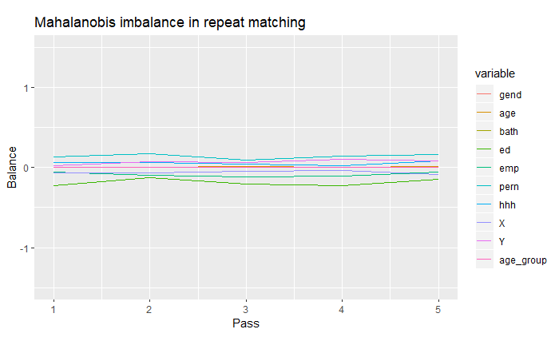

```r
plot_imbalance_over_time(matches,"Mahalanobis imbalance in repeat matching")
```